# Group Project

A3

2022-08-03

## Introduction

With increasingly unaffordable housing having become a chronic social issue in Canada over the last two decades, the factors that contribute to rising housing cost have been in focus, and hotly debated among policy makers and voters alike. Here, we would like to measure the relative importance of the commonly referred contributors of rising cost of housing: interest rate, immigration, earnings increases, and general increase in consumer prices. We will explore and quantify the significance of the predictors or drivers of rising housing price above. Furthermore, by better understanding possible causes and predictors of the present day problem, we aim to better inform policymakers and their electorate on the most important issues underlying the unaffordable housing markets of the metropolitan Canada.

TODO: we need some references for this introduction.

### Variables

[output not shown]

## Analysis

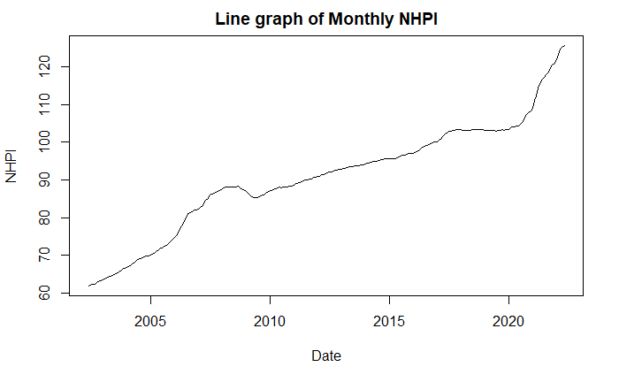

```r
plot(date, dataset$NHPI, main="Line graph of Monthly NHPI",
  xlab="Date", ylab="NHPI", type = 'l',
  )
```

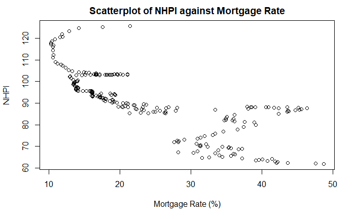

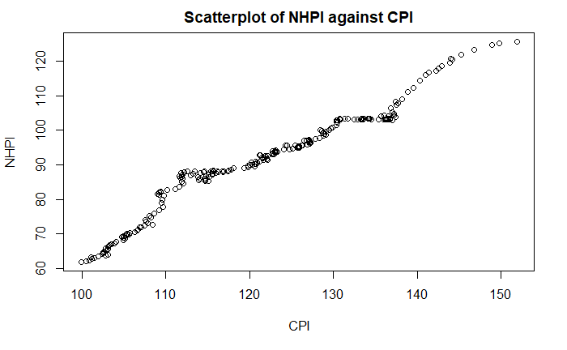

```r
plot(dataset$CPI, dataset$NHPI, main="Scatterplot of NHPI against CPI",
  xlab="CPI", ylab="NHPI",
  )
```

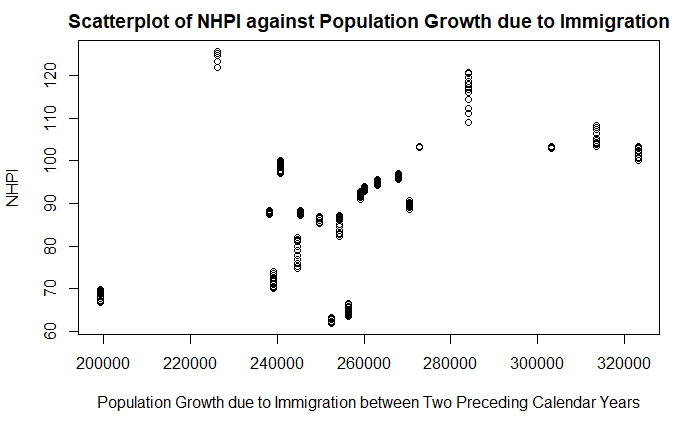

```r
plot(dataset$Immigrants, dataset$NHPI, main="Scatterplot of NHPI against Population Growth due to Immigration",
  xlab="Population Growth due to Immigration between Two Preceding Calendar Years", ylab="NHPI",
  )
```

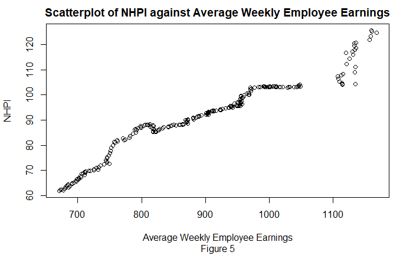

```r
plot(dataset$Earnings, dataset$NHPI, main="Scatterplot of NHPI against Average Weekly Employee Earnings", sub="Figure 5",
  xlab="Average Weekly Employee Earnings", ylab="NHPI",
  )
```

What is wrong with the tail? Covid, that’s what. The jump happened in March 2020. TODO: Maybe highlight the pandemic era data with a different color.

```r
library(rgl)
plot3d(z = dataset$NHPI, y = dataset$Earnings, x = date)
```

### Collinearity

We measured the collinearity with VIF.

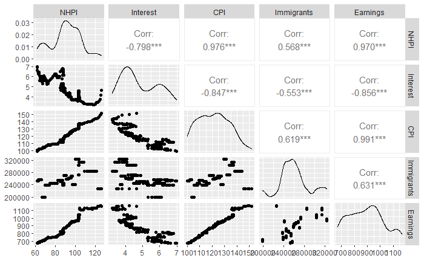

```r
model.fl <- lm(NHPI ~ ., dataset)
car::vif(model.fl)
```

```
  Interest        CPI Immigrants   Earnings
  3.752074  58.437414   1.671963  63.187098
```

TODO: explain the significance of VIF. VIF > 10 means collinearity may be a problem. The collinearity involving Earnings and CPI was addressed using an interaction term between Earnings and CPI.

### Transformation

TODO: justify based on the Q-Q plots of the fully linear model, and the model with an interaction term.

An interaction terms is added to our model to address the high collinearity of CPI and Earnings.

### Model Selection with Exhaustive Search

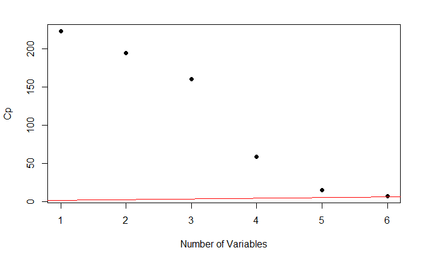

```r
plot(best_subsets$cp, pch = 19, xlab = "Number of Variables",
         ylab = "Cp")
abline(0,1, col='red')
```

TODO: summary of exhaustive search result as a table of number of variables, variables, $R^2$, $R^2_{adj}$ and $C_p$. You can get them from the following.

```
Subset selection object
Call: regsubsets.formula(NHPI ~ . + CPI * Earnings + I(Interest^2),
    data = dataset, method = "exhaustive")
6 Variables  (and intercept)
              Forced in Forced out
Interest          FALSE      FALSE
CPI               FALSE      FALSE
Immigrants        FALSE      FALSE
Earnings          FALSE      FALSE
I(Interest^2)     FALSE      FALSE
CPI:Earnings      FALSE      FALSE
1 subsets of each size up to 6
Selection Algorithm: exhaustive
         Interest CPI Immigrants Earnings I(Interest^2) CPI:Earnings
1  ( 1 ) " "      "*" " "        " "      " "           " "
2  ( 1 ) " "      "*" " "        " "      "*"           " "
3  ( 1 ) " "      "*" " "        "*"      " "           "*"
4  ( 1 ) " "      "*" " "        "*"      "*"           "*"
5  ( 1 ) " "      "*" "*"        "*"      "*"           "*"
6  ( 1 ) "*"      "*" "*"        "*"      "*"           "*"
[1] 0.9522666 0.9554736 0.9592062 0.9699909 0.9747847 0.9757803
[1] 0.9520661 0.9550978 0.9586876 0.9694801 0.9742459 0.9751566
[1] 223.20787 194.35584 160.44748  58.69533  14.57800   7.00000
```

TODO: create a table of R2, adjR2, and Cp.

We test 3 models. A full linear model, a model with an interaction term between CPI and average weekly earnings, and a model with the same interaction term and a quadratic term for the mortgage rate. The quadratic term was added based on Figure 2, and the residual plots of the fully linear model, and the model with an interaction term.

```r
model.fl <- lm(NHPI ~ ., dataset)
model.interaction <- lm(NHPI ~ . + CPI*Earnings, dataset)
model.quad <- lm(NHPI ~ . + CPI*Earnings + I(Interest^2), dataset)
```

```r
summary(model.fl)
```

```
Call:
lm(formula = NHPI ~ ., data = dataset)

Residuals:
    Min      1Q  Median      3Q     Max
-6.0647 -2.3888  0.4165  2.1951  4.8757

Coefficients:
              Estimate Std. Error t value Pr(>|t|)
(Intercept) -5.210e+01  6.350e+00  -8.205 1.52e-14 ***
Interest     1.606e+00  3.582e-01   4.485 1.14e-05 ***
CPI          9.135e-01  1.191e-01   7.667 4.64e-13 ***
Immigrants  -3.243e-05  8.744e-06  -3.709  0.00026 ***
Earnings     3.701e-02  1.146e-02   3.231  0.00141 **
---
Signif. codes:  0 ‘***’ 0.001 ‘**’ 0.01 ‘*’ 0.05 ‘.’ 0.1 ‘ ’ 1

Residual standard error: 2.939 on 235 degrees of freedom
Multiple R-squared:  0.9588,    Adjusted R-squared:  0.9581
F-statistic:  1369 on 4 and 235 DF,  p-value: < 2.2e-16
```

```r
summary(model.interaction)
```

```
Call:
lm(formula = NHPI ~ . + CPI * Earnings, data = dataset)

Residuals:
    Min      1Q  Median      3Q     Max
-6.0336 -1.4034 -0.1952  1.3450  6.4915

Coefficients:
               Estimate Std. Error t value Pr(>|t|)
(Intercept)  -1.832e+02  1.254e+01 -14.608  < 2e-16 ***
Interest      2.967e+00  3.111e-01   9.537  < 2e-16 ***
CPI           1.797e+00  1.229e-01  14.620  < 2e-16 ***
Immigrants   -4.530e-05  7.107e-06  -6.374  9.7e-10 ***
Earnings      2.011e-01  1.704e-02  11.804  < 2e-16 ***
CPI:Earnings -1.143e-03  9.994e-05 -11.440  < 2e-16 ***
---
Signif. codes:  0 ‘***’ 0.001 ‘**’ 0.01 ‘*’ 0.05 ‘.’ 0.1 ‘ ’ 1

Residual standard error: 2.359 on 234 degrees of freedom
Multiple R-squared:  0.9736,    Adjusted R-squared:  0.973
F-statistic:  1726 on 5 and 234 DF,  p-value: < 2.2e-16
```

```r
summary(model.quad)
```

```
Call:
lm(formula = NHPI ~ . + CPI * Earnings + I(Interest^2), data = dataset)

Residuals:
    Min      1Q  Median      3Q     Max
-4.5034 -1.7755 -0.0101  1.1786  6.1552

Coefficients:
                Estimate Std. Error t value Pr(>|t|)
(Intercept)   -1.735e+02  1.222e+01 -14.193  < 2e-16 ***
Interest      -6.419e+00  2.074e+00  -3.095  0.00221 **
CPI            2.017e+00  1.274e-01  15.828  < 2e-16 ***
Immigrants    -4.819e-05  6.852e-06  -7.033 2.22e-11 ***
Earnings       2.025e-01  1.636e-02  12.380  < 2e-16 ***
I(Interest^2)  8.988e-01  1.966e-01   4.573 7.82e-06 ***
CPI:Earnings  -1.266e-03  9.964e-05 -12.709  < 2e-16 ***
---
Signif. codes:  0 ‘***’ 0.001 ‘**’ 0.01 ‘*’ 0.05 ‘.’ 0.1 ‘ ’ 1

Residual standard error: 2.264 on 233 degrees of freedom
Multiple R-squared:  0.9758,    Adjusted R-squared:  0.9752
F-statistic:  1565 on 6 and 233 DF,  p-value: < 2.2e-16
```

TODO: make a note on the Adjusted R-squared. It’s the largest for the quadratic model.

### Serial Correlation

The standard assumptions of linear regression includes serial independence of data. The Durbin-Watson statistic was used to measure the serial correlation of our model [2].

```r
library(lmtest)
dwtest(formula = NHPI ~ . + CPI * Earnings + I(Interest^2), data = dataset)
```

```
    Durbin-Watson test

data:  NHPI ~ . + CPI * Earnings + I(Interest^2)
DW = 0.12257, p-value < 2.2e-16
alternative hypothesis: true autocorrelation is greater than 0
```

The Durbin-Watson statistic for our model is close to 0 with a very small $p$ value, indicating high positive serial correlation. The standard errors of coefficients are underestimated if the data is positively serially correlated.

### Newey-West Standard Errors

Because the standard errors of coefficients are underestimated due to the high serial correlation, the Newey-West standard errors should be used instead [1]. The Newey-West standard errors are robust to both Heteorscedasticity and Autocorrelation (HAC).

```r
library(sandwich)
nw.fl <- NeweyWest(model.fl, lag=NULL, prewhite=FALSE, adjust=TRUE, verbose=TRUE)
```

```
Lag truncation parameter chosen: 11
```

```r
coeftest(model.fl, vcov.=nw.fl)
```

```
t test of coefficients:

               Estimate  Std. Error t value Pr(>|t|)
(Intercept) -5.2104e+01  1.8492e+01 -2.8177 0.005249 **
Interest     1.6062e+00  1.1993e+00  1.3393 0.181760
CPI          9.1346e-01  3.4171e-01  2.6732 0.008040 **
Immigrants  -3.2434e-05  2.7104e-05 -1.1966 0.232651
Earnings     3.7012e-02  3.4291e-02  1.0794 0.281535
---
Signif. codes:  0 ‘***’ 0.001 ‘**’ 0.01 ‘*’ 0.05 ‘.’ 0.1 ‘ ’ 1
```

The significance of some of the variables appear lower, and most of them appear insignificant when corrected for serial correlation.

```r
nw.inter <- NeweyWest(model.interaction, lag=NULL, prewhite=FALSE, adjust=TRUE, verbose=TRUE)
```

```
Lag truncation parameter chosen: 11
```

```r
coeftest(model.interaction, vcov.=nw.inter)
```

```
t test of coefficients:

                Estimate  Std. Error t value  Pr(>|t|)
(Intercept)  -1.8316e+02  3.7007e+01 -4.9494 1.424e-06 ***
Interest      2.9668e+00  7.9158e-01  3.7479 0.0002247 ***
CPI           1.7966e+00  3.8574e-01  4.6577 5.364e-06 ***
Immigrants   -4.5302e-05  2.4632e-05 -1.8391 0.0671617 .
Earnings      2.0109e-01  4.8367e-02  4.1577 4.513e-05 ***
CPI:Earnings -1.1433e-03  3.0714e-04 -3.7225 0.0002471 ***
---
Signif. codes:  0 ‘***’ 0.001 ‘**’ 0.01 ‘*’ 0.05 ‘.’ 0.1 ‘ ’ 1
```

When the interaction term is included, the significance of the predictor variables are preserved.

```r
nw.quad <- NeweyWest(model.quad, lag=NULL, prewhite=FALSE, adjust=TRUE, verbose=TRUE)
```

```
Lag truncation parameter chosen: 11
```

```r
coeftest(model.quad, vcov.=nw.quad)
```

```
t test of coefficients:

                 Estimate  Std. Error t value  Pr(>|t|)
(Intercept)   -1.7347e+02  3.5139e+01 -4.9367 1.515e-06 ***
Interest      -6.4194e+00  6.0028e+00 -1.0694   0.28599
CPI            2.0166e+00  3.3870e-01  5.9539 9.563e-09 ***
Immigrants    -4.8194e-05  2.3853e-05 -2.0204   0.04448 *
Earnings       2.0251e-01  4.5826e-02  4.4191 1.519e-05 ***
I(Interest^2)  8.9882e-01  5.4340e-01  1.6541   0.09946 .
CPI:Earnings  -1.2664e-03  2.8078e-04 -4.5103 1.026e-05 ***
---
Signif. codes:  0 ‘***’ 0.001 ‘**’ 0.01 ‘*’ 0.05 ‘.’ 0.1 ‘ ’ 1
```

### Residuals

TODO: summarize the final linear model. Make a note on the interaction between CPI and Earnings being significant. The coefficient for the interaction is negative, which means the positive impact of earnings and CPI on NHPI is attenuated when these values changes in the same direction. In other words, if changes in average wage stay in parity with CPI, housing prices tend to be a little lower.

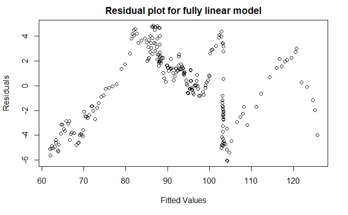

```r
plot(dataset$NHPI, model.fl$residuals, main="Residual plot for fully linear model",
  xlab="Fitted Values", ylab="Residuals")
```

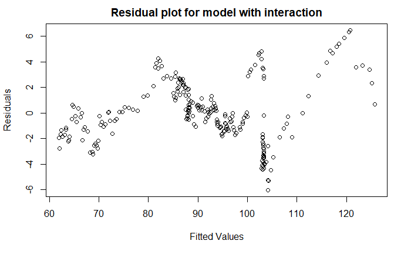

```r
plot(dataset$NHPI, model.interaction$residuals, main="Residual plot for model with interaction",
  xlab="Fitted Values", ylab="Residuals")
```

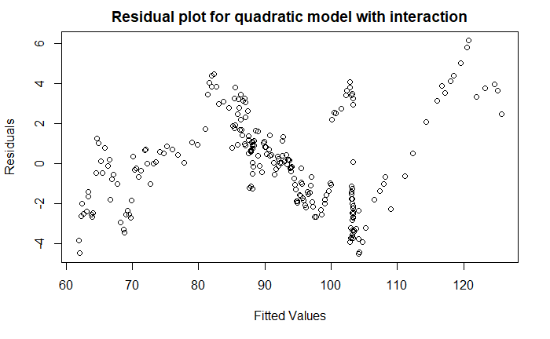

```r
plot(dataset$NHPI, model.quad$residuals, main="Residual plot for quadratic model with interaction",
  xlab="Fitted Values", ylab="Residuals")
```

TODO: Is there a pattern? It seems we cannot explain with all variance in NHPI with the predictors here. We may need more variables for a more complete model.

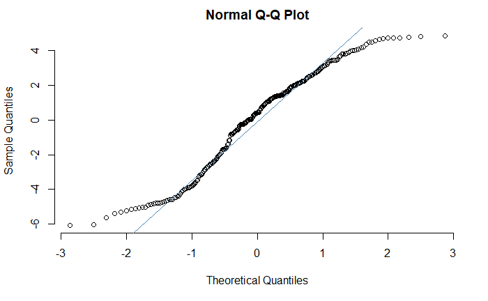

```r
qqnorm(model.fl$residuals, frame = FALSE)
qqline(model.fl$residuals, col = "steelblue")
```

The error distribution of the fully linear model is light-tailed, and the normality-of-errors assumption may not hold. Because the right tail is light, it may produce smaller errors for future predictions.

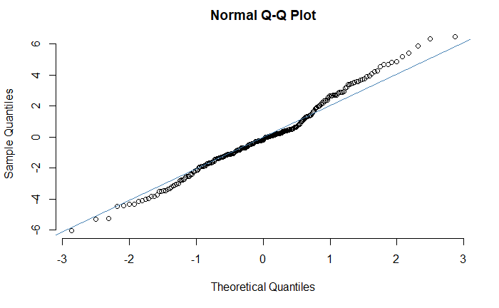

```r
qqnorm(model.interaction$residuals, frame = FALSE)
qqline(model.interaction$residuals, col = "steelblue")
```

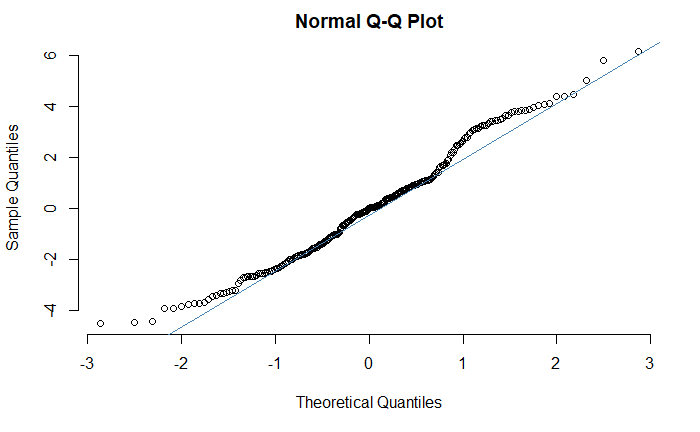

```r
qqnorm(model.quad$residuals, frame = FALSE)
qqline(model.quad$residuals, col = "steelblue")
```

The distribution of the residual is heavy-tailed, but not extremely so. The normal error assumption seems to mostly hold.

### Forecast Tests with a Holdout Set

We cannot do a cross-validation on a time series data. We instead train our model on the first 80% of the data, and test it on the last 20% of the data. But this may not be a valid way to evaluate the model involving a time series. TODO: why not? The root mean square prediction errors are used to evauate the three models.

```r
train <- 1:as.integer(dim(dataset)[1]*.8)

reg1 <- lm(NHPI ~ . , dataset[train,])
sqrt(sum((dataset$NHPI[-train] - predict(reg1, dataset[-train,]))^2))/length(dataset$NHPI[-train])
```

```
[1] 1.426268
```

```r
reg1 <- lm(NHPI ~ . + CPI*Earnings, dataset[train,])
sqrt(sum((dataset$NHPI[-train] - predict(reg1, dataset[-train,]))^2))/length(dataset$NHPI[-train])
```

```
[1] 1.130076
```

```r
reg1 <- lm(NHPI ~ . + CPI*Earnings + I(Interest^2), dataset[train,])
sqrt(sum((dataset$NHPI[-train] - predict(reg1, dataset[-train,]))^2))/length(dataset$NHPI[-train])
```

```
[1] 1.159623
```

### Forecasts Using Models

The real NHPI for June 2022 was 125.9.

```r
# modified to produce a prediction interval
predict.interval <- function(x, covm, newdata){
    tt <- delete.response(terms(x))
    m.mat <- model.matrix(tt, data=newdata)
    m.coef <- x$coef
    fit <- as.vector(m.mat %*% x$coef)
    se <- sqrt(diag(m.mat%*%covm%*%t(m.mat)))

    interval <- c(-1,1) * se * qt(.975, length(dataset$NHPI) - 5 - 1) + fit

    return(data.frame(fit=fit, interval=interval, se=se))
  }

# June
predict.interval(model.quad, nw.quad, data.frame(CPI=152.9, Immigrants=226203, Earnings=1159.85, Interest=1.75))
```

| fit | interval | se |
| --- | --- | --- |
| 125.7726 | 110.5189 | 7.742361 |
| 125.7726 | 141.0262 | 7.742361 |

```r
# July with imputed CPI and Earnings (assuming every stays the same except for the interest rate)
predict.interval(model.quad, nw.quad, data.frame(CPI=155.9, Immigrants=226203, Earnings=1159.85, Interest=2.75))
```

| fit | interval | se |
| --- | --- | --- |
| 125.041 | 113.7833 | 5.714099 |
| 125.041 | 136.2986 | 5.714099 |

```r
# June
predict.interval(model.fl, nw.fl, data.frame(CPI=152.9, Immigrants=226203, Earnings=1159.85, Interest=1.75))
```

| fit | interval | se |
| --- | --- | --- |
| 125.9675 | 119.3358 | 3.366086 |
| 125.9675 | 132.5992 | 3.366086 |

```r
# July with imputed CPI and Earnings (assuming every stays the same except for the interest rate)
predict.interval(model.fl, nw.fl, data.frame(CPI=155.9, Immigrants=226203, Earnings=1159.85, Interest=2.75))
```

| fit | interval | se |
| --- | --- | --- |
| 130.3142 | 123.1322 | 3.64536 |
| 130.3142 | 137.4961 | 3.64536 |

```r
# June
predict.interval(model.interaction, nw.inter, data.frame(CPI=152.9, Immigrants=226203, Earnings=1159.85, Interest=1.75))
```

| fit | interval | se |
| --- | --- | --- |
| 116.9696 | 108.3616 | 4.369201 |
| 116.9696 | 125.5776 | 4.369201 |

```r
# July with imputed CPI and Earnings (assuming every stays the same except for the interest rate)
predict.interval(model.interaction, nw.inter, data.frame(CPI=155.9, Immigrants=226203, Earnings=1159.85, Interest=2.75))
```

| fit | interval | se |
| --- | --- | --- |
| 121.3481 | 111.9506 | 4.769923 |
| 121.3481 | 130.7456 | 4.769923 |

TODO: The forecasts cannot be directly compared evaluated on the prediction errors. So focus on the standard errors instead.

TODO: choose the final model.

TODO: Summarize the final model. Use the results from coeftest.

## Conclusion

TODO: Which was the most significant predictor? The government can directly control the interest rate, and immigration. It can also affect average earnings to some degree. Which one would be the best way to lower housing price if political considerations were not a concern? Can we predict the price trend in the future based on the Bank of Canada’s recent decisions to increase the interest rate?

When adjusted for CPI and earnings, immigration and the interest rate seem to affect the NHPI in the opposite directions that they are typically associated with in the literature. High immigration lowers NHPI, and high interest rate is associated with high NHPI.

## References

Newey, Whitney K; West, Kenneth D (1987). “A Simple, Positive Semi-definite, Heteroskedasticity and Autocorrelation Consistent Covariance Matrix” (PDF). Econometrica. 55 (3): 703–708. doi:10.2307/1913610. JSTOR 1913610.

Durbin, J.; Watson, G. S. (1971). “Testing for serial correlation in least squares regression.III”. Biometrika. 58 (1): 1–19. doi:10.2307/2334313

Statistics Canada. Table 18-10-0205-01 New housing price index, monthly https://www150.statcan.gc.ca/t1/tbl1/en/tv.action?pid=1810020501

Statistics Canada. Table 34-10-0145-01 Canada Mortgage and Housing Corporation, conventional mortgage lending rate, 5-year term https://www150.statcan.gc.ca/t1/tbl1/en/tv.action?pid=3410014501

Statistics Canada. Table 17-10-0008-01 Estimates of the components of demographic growth, annual https://www150.statcan.gc.ca/t1/tbl1/en/tv.action?pid=1710000801

Statistics Canada. Table 18-10-0004-01 Consumer Price Index, monthly, not seasonally adjusted https://www150.statcan.gc.ca/t1/tbl1/en/tv.action?pid=1810000401

Statistics Canada. Table 14-10-0223-01 Employment and average weekly earnings (including overtime) for all employees by province and territory, monthly, seasonally adjusted https://www150.statcan.gc.ca/t1/tbl1/en/tv.action?pid=1410022301